# Investigating effects of tumor stromal content on Pleiotrophin (PTN) signaling in mouse models of Triple Negative Breast Cancer

Angel F. Alvarado Velez

2025-07-16

## What is Pleiotrophin?

This project explores the role of **pleiotrophin (PTN)**, a heparin-binding growth factor, in the tumor microenvironment (TME) of breast cancer. PTN has been implicated in promoting tumor growth, angiogenesis, and metastasis, yet its signaling dynamics and transcriptional impact remain incompletely understood.

## Objectives

This project aims to investigate the influence of **pleiotrophin** on tumor development, specifically focusing on its expression and activity within the TME. Using two experimental datasets, one derived from CT3-tagged mouse models and one derived literature, we will analyze how PTN expression correlates with changes in cellular behavior and tumor progression. By addressing this, our study has the potential to bring new insights into the functional role of PTN in breast cancer and to the development of therapeutic targets. (like PTN/NRP-1 interaction)

## a. Linna Procedure with GSE Dataset

1. **Import Libraries**

```r
library(limma)
library(tidyverse)
```

2. **Put path to input file here**

```r
inputFile <- "GSE200431_all_dep_ctrl_noNA.csv"
```

3. **Import log2CPM data into R**

```r
log2CPM_matrix <- read.csv(inputFile)
```

4. **Create data.matrix from log2CPM_matrix, with gene symbols as rownames**

```r
log2CPM_matrix <-
  log2CPM_matrix %>%
  distinct(symbol, .keep_all = TRUE) %>%
  column_to_rownames("symbol") %>%
  dplyr::select(-X) %>%
  as.matrix()
```

5. **Create a vector of sample names & use brackets to subset samples to analyze**

```r
whichSamples <- colnames(log2CPM_matrix)
whichSamples <- whichSamples[-c(1:12, 19:24)]
```

6. **Extract treatment names from group names**

```r
group <- str_remove((str_extract(whichSamples, "[_][A-Za-z]+")), "_")
group <- as.factor(group)
```

7. **Create design matrix for linear model**

```r
design <- model.matrix(~ 0 + group)
colnames(design) <- levels(group)
design
```

8. **Fit linear model to log2CPM data**

```r
fit <- lmFit(log2CPM_matrix[, whichSamples], design)
```

9. **Define contrast(s)**

```r
contrast.matrix <- makeContrasts(CntrlvsSH= plko - shPTN,levels=design)
fit2 <- contrasts.fit(fit, contrast.matrix)
fit2 <- eBayes(fit2)
```

10. **Extract results**

```r
topTable(fit2, coef="CntrlvsSH", lfc = 0, number = 20)
```

11. **Create new file**

```r
cooltable <- topTable(fit2, coef="CntrlvsSH", lfc = 0, number = 20)
```

12. **Filter tale to select genes with adjusted p-value < 0.5 & log2 fold change > 1 or < -1**

```r
library(dplyr)
coolfilteredgenes <- cooltable %>%
  filter(adj.P.Val < 0.5 & (logFC > 1 | logFC < -1))
```

13. **Write table to CSV file**

```r
write.csv(coolfilteredgenes, "GSEFiltered_PTN_Signature.csv", row.names = FALSE)
```

## b. Fltered PTN Genes Table

|  | logFC | AveExpr | t | P.Value | adj.P.Val | B |
| --- | --- | --- | --- | --- | --- | --- |
| Serpinf1 | -4.334540070666668 | 2.148671594666667 | -33.16574132544203 | 8.2181485203694e-08 | 0.000993163248686642 | 7.790738526674127 |
| Htra1 | -1.839510226333333 | 6.203147972500001 | -22.42015505348627 | 7.760230078819303e-07 | 0.002708567790629733 | 6.445245678353168 |
| Spsb4 | -1.602701614666666 | 4.141970913333333 | -20.49126845317284 | 1.297227799934118e-06 | 0.002708567790629733 | 6.067420794229869 |
| Gm4204 | 1.645216223999999 | 6.293736061666666 | 20.42215587144128 | 1.322475248118407e-06 | 0.002708567790629733 | 6.052766707035766 |
| Cfdp1 | 1.588682702666665 | 6.791164765 | 20.03114809360574 | 1.476643602969064e-06 | 0.002708567790629733 | 5.968285366568391 |
| Mtss2 | -1.733812909333333 | 5.881040186666667 | -19.43817414740452 | 1.752538070201455e-06 | 0.002708567790629733 | 5.834869664165931 |
| Aass | -2.229868926666667 | 4.464982219333333 | -19.34009773373126 | 1.803783300068483e-06 | 0.002708567790629733 | 5.812164269894475 |
| Slc25a21 | -1.676131456333334 | 3.2109889235 | -18.7910026059726 | 2.125317345831696e-06 | 0.002708567790629733 | 5.681547127672698 |
| Itga7 | -1.625885913333334 | 5.946291953333333 | -18.72961907924985 | 2.165275269181387e-06 | 0.002708567790629733 | 5.666567214491436 |
| Atp9a | -2.070110382 | 2.723648676666667 | -18.24103690748091 | 2.516714259245402e-06 | 0.002708567790629733 | 5.544514649340681 |

[output cut: 10 more lines]

1. **Dowload Packages**

```r
BiocManager::install("ComplexHeatmap")
library(ComplexHeatmap)
library(dplyr)
```

2. **Delete columns of log2CPM Matrix, only having the 6 relevant columns**

```r
log2CPM_matrix_filtered <- log2CPM_matrix[, -c(1:12, 19:25)]
```

```r
top50_genes_filtered <- coolfilteredgenes %>%
  filter(adj.P.Val < 0.05) %>%
  arrange(desc(abs(logFC))) %>%
  slice(1:50)
```

3. **Subset the Data, selecting a specific portion of the data that meet the particular requirements**

```r
log2CPM_top50 <- log2CPM_matrix_filtered[rownames(log2CPM_matrix_filtered) %in% rownames(top50_genes_filtered), ]
```

4. **Mean centering the data, substracting the mean expression from each row. Making it easier to identify**

```r
log2CPM_top50_centered <- t(scale(t(log2CPM_top50), center = TRUE, scale = FALSE))
```

5. **Creating the heatmap**

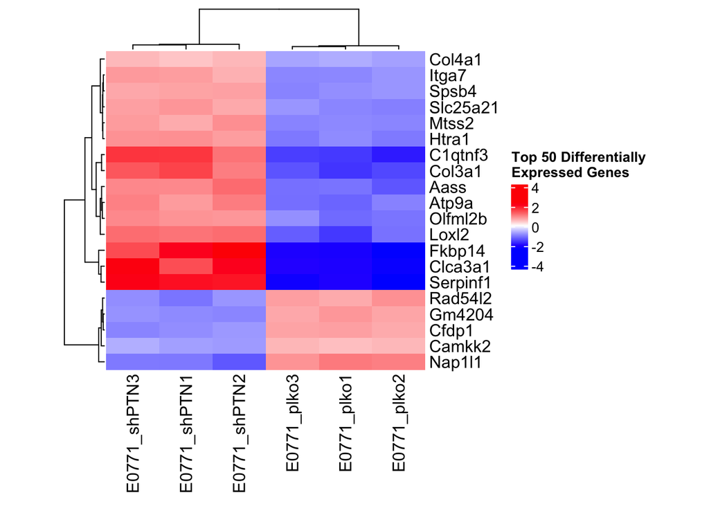

```r
  Heatmap(log2CPM_top50_centered,
          col = colorRampPalette(c("blue", "white", "red"))(256),
          show_column_names = TRUE,
          show_row_names = TRUE,
          width = unit(8, "cm"),
          height = unit(8, "cm"),
          name = "Top 50 Differentially\nExpressed Genes")
```